# Arvore de Regressão

```
                                  ÁRVORE DE REGRESSÃO
```

As árvores de decisão são modelos baseados em conjunções e disjunções de regras que podem facilmente ser representadas sob a forma de uma árvore. Neste trabalho utiliso arvore de decisão para resolver um problema de Regressão (arvore de regressão).

Consideremos os dados “Song popularity Data” do “Kaggle”, pretende-se criar um modelo preditivo da popularidade de musicas “Song popularity Data” com base em determinadas variaveis como a energia, a acustica, a instrumentalidade, a vivacidade, entre outros. A arvore de regressao é guiado pelo RMSE e não por medidas de impureza.

```r
#__________________________________________________
# Carregue o conjunto de dados:
song_data <- read.csv("data/song_data.csv")#chama o conjunto de dados
View(song_data) #para visualizar o conjunto de dados
```

Vamos eliminar a primeira coluna nos dados

```r
song_data1=song_data[,-1]
View(song_data1)
```

Vamos dividir o conjunto de dados em dados de treio e de teste.

```r
library(readr) #clamar o pacote readr
getwd()
```

```
[1] "/Users/pedrovenancio/Desktop/Universidade/Mestrado/2ºAno/2ºSemestre(2)/Aprendizagem Computacional/Popularidade_de_musicas"
```

```r
#___________
set.seed(1234) #fazer a mesma divisão dos conjuntos de teste e
#treino sempre que se executa o código
ind.tr=sample(1:nrow(song_data1),0.7*nrow(song_data))
song.tr=song_data1[ind.tr,] #Dados para treino
song.te=song_data1[-ind.tr,] #Dados para teste
```

Existem diferentes pacotes para modelar com árvores de decisão. Aqui usaremos o tree.

```r
install.packages("tree") #instalar o pacote tree (diz se a arvore é de classificação ou de regressão)
library(tree) #chamar o pacote tree
```

Ajustamos uma árvore de regressão:

```r
song.tree=tree(song_popularity~.,data=song.tr) #ajusta uma árvore
summary(song.tree) # faz um resumo da árvore ajustada
```

```
Regression tree:
tree(formula = song_popularity ~ ., data = song.tr)
Variables actually used in tree construction:
[1] "instrumentalness" "loudness"         "energy"
Number of terminal nodes:  4
Residual mean deviance:  455 = 5997000 / 13180
Distribution of residuals:
   Min. 1st Qu.  Median    Mean 3rd Qu.    Max.
-60.010 -12.010   2.998   0.000  15.340  50.000
```

A função tree identificou automaticamente que se trata de um problema de regressao e as variâveis que ganharam os nós para construir a árvore são “instrumentalness”, “loudness” e “energy” . De facto, as árvores de decisão têm esta vantagem: apenas utilizam as variáveis essenciais para resolver o problema (efetuam uma seleção de variáveis). A árvore contém 4 folhas e tem um erro de treino de cerca de 455 em Média.

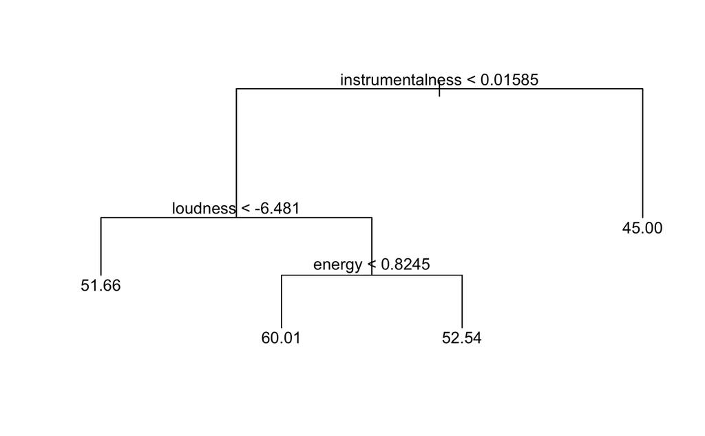

```r
plot(song.tree) #Apresenta as linhas da árvore
text(song.tree,pretty=0)#acrescenta  as variáveis que ganharam cara nó e as condições
```

```
1.1- O PROCESSO DE PODA
```

Avaliamos agora a possibilidade de obter ganhos com a poda da árvore:

```r
song.tree.cv=cv.tree(song.tree) #aplica o processo da poda
song.tree.cv # faz um resumo do processo aplicado
```

```
$size
[1] 4 3 2 1

$dev
[1] 6075233 6171227 6183843 6338959

$k
[1]      -Inf  75015.50  82211.31 183915.04

$method
[1] "deviance"

attr(,"class")
[1] "prune"         "tree.sequence"
```

Neste caso, a árvore original é a de melhor performance (ela apresenta menor erro com 4 folhas), pelo que não se aplica qualquer estratégia de poda.

Podemos assim avaliar no conjunto de teste:

```r
pred=predict(song.tree,newdata=song.te) #avalia o madelo criado no conjunto de teste.

sqrt(mean((pred-song.te$song_popularity)^2))# calcula RMSE (podemos utilizar o MAPE para obter os erros em percentágens)
```

```
[1] 21.47812
```

1.2-A ÁRVIRE TMAX

Mas, e se os critérios de paragem pré-estabelecidos no R são demasiado exigentes? Poderá a árvore construída com 4 folhas não ser a melhor porque o processo de construção terminou cedo demais? Podemos sempre forçar a árvore Tmax e aplicar a estratégia de poda.

```r
song.tmax=tree(song_popularity~.,data=song.tr, control = tree.control(nrow(song.tr),mindev=0.0005,minsize=2))
# mindev- controla o erro mínimo após a divisão.
#minsize-define o tamanho mínimo do nó antes da divisão.~
summary(song.tmax)# apresenta o resumo da árvore criada
```

```
Regression tree:
tree(formula = song_popularity ~ ., data = song.tr, control = tree.control(nrow(song.tr),
    mindev = 5e-04, minsize = 2))
Number of terminal nodes:  350
Residual mean deviance:  307.7 = 3949000 / 12830
Distribution of residuals:
   Min. 1st Qu.  Median    Mean 3rd Qu.    Max.
-67.470  -9.503   2.612   0.000  12.120  48.920
```

A árvore obtida tem 350 folhas e um erro de aproximadamente 307. Á seguir temos duas representações em que apenas uma apresenta as variáveis que ganhou cada nó.

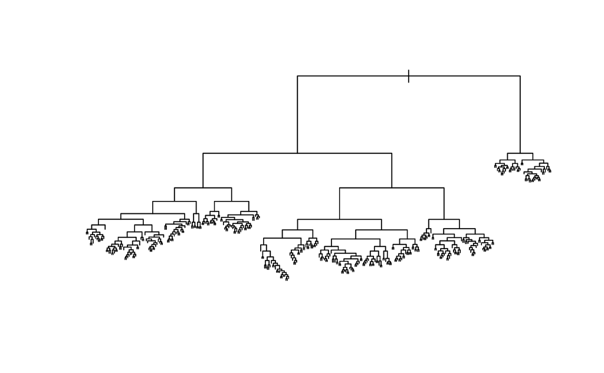

```r
plot(song.tmax) #Apresenta as linhas da árvore
```

[figure not shown]

```r
plot(song.tmax) #Apresenta as linhas da árvore
text(song.tmax,pretty=0)#acrescenta  as variáveis que ganharam cara nó e as condições.
```

1.3- A PODA DA ÁRVIRE TMAX

Aplicamos agora a estratégia de poda:

```r
song.tmax.cv=cv.tree(song.tmax) #aplica a poda
song.tmax.cv # faz um resumo da processo de poda
```

```
$size
  [1] 350 349 348 347 345 343 342 341 340 339 338 337 335 333 332 331 330 329 328 326 325 324 322 320 319 318 317 316 315
 [30] 314 313 312 310 309 308 307 305 304 303 301 300 299 298 297 295 293 291 290 289 288 287 285 284 282 281 280 279 277
 [59] 276 275 273 272 271 269 267 266 265 264 262 260 258 254 253 252 250 249 248 246 244 243 242 241 240 239 238 237 236
 [88] 235 234 233 232 231 230 229 227 226 225 224 223 222 221 220 219 218 217 216 215 213 208 207 206 205 204 203 199 198
[117] 197 193 192 191 190 188 187 185 182 180 179 178 177 174 173 172 171 170 165 164 163 162 160 153 152 151 150 148 142
[146] 141 140 138 137 135 134 131 130 124 122 121 120 116 115 114 110 109 106 104 102 101  99  98  97  93  92  90  89  88
[175]  84  83  82  80  79  77  74  73  72  70  67  66  65  64  60  59  56  55  54  53  52  51  49  48  47  46  45  44  43
[204]  39  37  36  34  33  31  30  29  28  27  26  25  24  23  22  21  19  16  15  14  13  12  11  10   9   8   7   6   5
[233]   4   3   2   1

$dev
  [1] 6044785 6044785 6044785 6044785 6044785 6044785 6044785 6044785 6044785 6044785 6044785 6044785 6044785 6044785
 [15] 6044785 6044785 6044785 6044785 6044785 6044785 6044785 6044785 6044785 6044785 6044785 6044785 6044785 6044785
 [29] 6044785 6044785 6044785 6044785 6044785 6044785 6044785 6044785 6044785 6044785 6044785 6044785 6044785 6044785
```

[output cut: 46 more lines]

Como podemos observar, entre 4 e 350 folhas a quantidade de erro é sempre a mesma (6044785) tornando- se óbvio que a árvore com 4 folhas tem a mesma performance 350 folhas. Vejamos este resultado no gráfico que se segue:

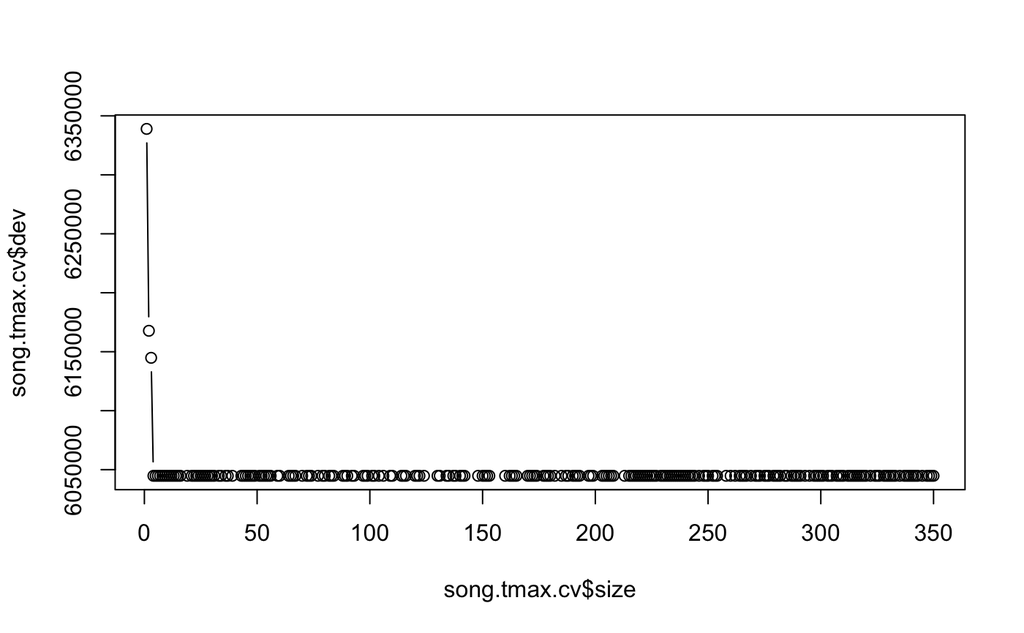

```r
plot(song.tmax.cv$size,song.tmax.cv$dev,type="b")
```

```r
#O comando "type" especifica o tipo de gráfico. Neste caso, "b"
#indica que quero um gráfico de disperssão com linhas conectando
#os pontos.
```

Já sabemos que entre perfórmances semelhantes é preferível o modelo mais ssímples. Portanto, devemos podar a árvore de forma que fique com apenas 4 folhas.

Vamos aplicar a poda.

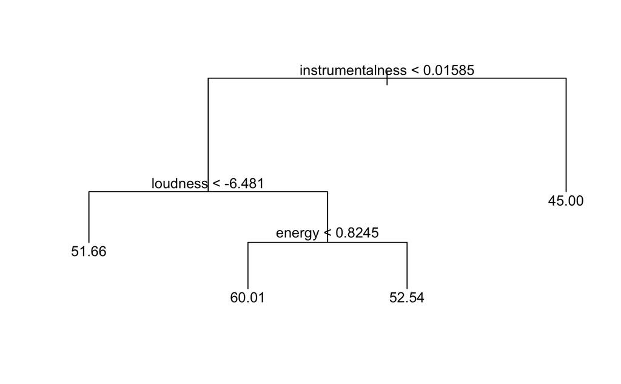

```r
prune.song.tmax.tree = prune.tree(song.tmax, best = 4, method = "deviance") # aplicar a pode de forma que a árvore podada tenha 4 folhas, conforme indicado no processo.
plot(prune.song.tmax.tree) #Apresenta as linhas da árvore
text(prune.song.tmax.tree,pretty=0) #acrescenta  as variáveis que ganharam cara nó e as condições.
```

Cocluimos que a árvore óptima tem mesmo quatro folhas.